# The ToothGrowth Data Analysis

Manuel A. Cerda R.

July 31th, 2016

# Overview

The objective of this analysis is to explore the ToothGrowth dataset from R collection of datasets.

The dataset consists of 60 observations, length of odontoblasts (teeth) in each of 10 guinea pigs at each of three dose levels of Vitamin C (0.5, 1 and 2 mg) with each of two delivery methods (orange juice or ascorbic acid).

### Instructions

1.- Load the ToothGrowth data and perform some basic exploratory data analysis

2.- Provide a basic summary of the data.

3.- Use confidence intervals and/or hypothesis tests to compare tooth growth by supp and dose. (Only use the techniques from class, even if there’s other approaches worth considering)

4.- State your conclusions and the assumptions needed for your conclusions.

### Data Processing

```r
data("ToothGrowth")
summary(ToothGrowth)
```

```
##       len        supp         dose
##  Min.   : 4.20   OJ:30   Min.   :0.500
##  1st Qu.:13.07   VC:30   1st Qu.:0.500
##  Median :19.25           Median :1.000
##  Mean   :18.81           Mean   :1.167
##  3rd Qu.:25.27           3rd Qu.:2.000
##  Max.   :33.90           Max.   :2.000
```

### Data Analysis

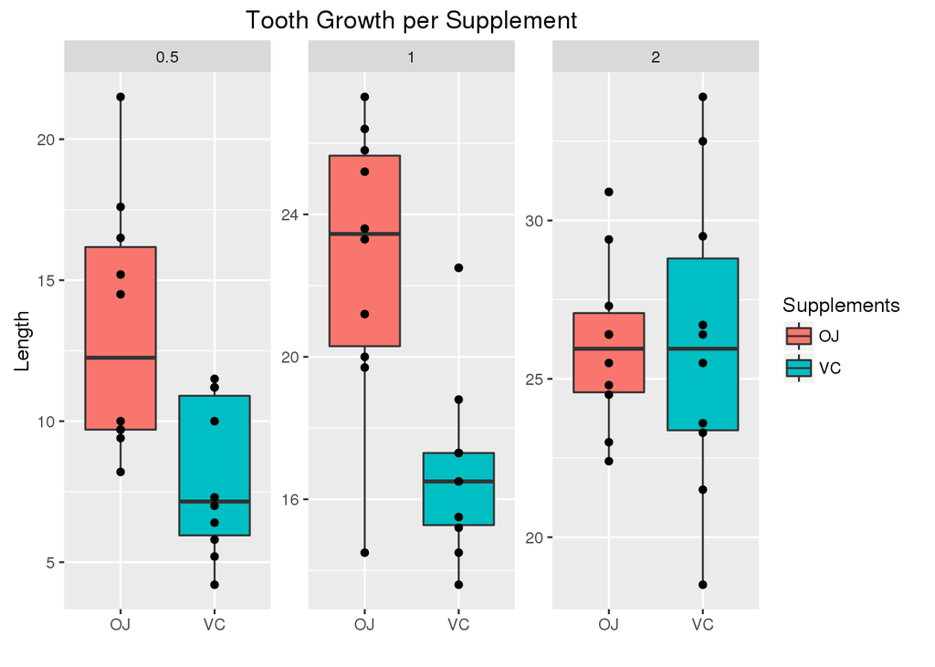

```r
require(ggplot2)
g <- ggplot(data = ToothGrowth, aes(x=supp, y=len))
g <- g + geom_boxplot(aes(fill=supp))
g <- g + geom_point(aes(y=len, group=supp), position = position_dodge(width=0.75))
g <- g + facet_wrap( ~ dose, scales="free")
g <- g + xlab("") + ylab("Length") + ggtitle("Tooth Growth per Supplement")
g <- g + guides(fill=guide_legend(title="Supplements"))
g
```

The Tooth Growth is affected by the supplement intake but also by the dose/quantity administered.

Can we really conclude that Orange Juice/Ascorbic Acid is a cause of Tooth Growth?

Considering testing the hypothesis that there is NO mean increased in Tooth Growth witht an higher dosage of the supplements.

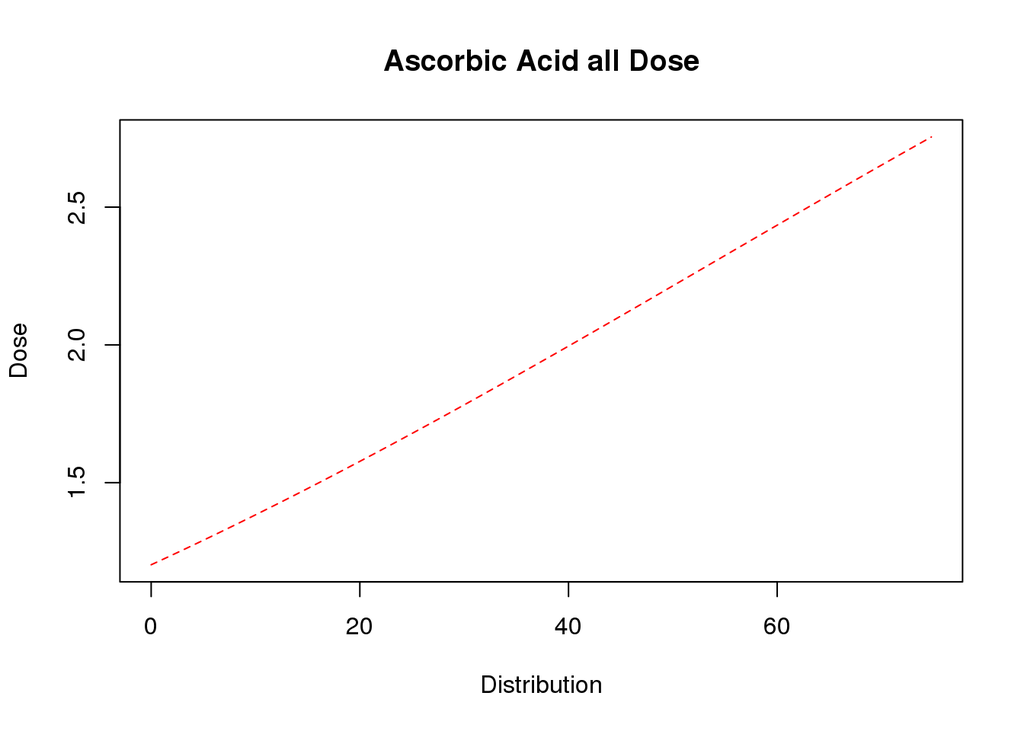

```r
require(graphics)

ojDose <- subset(ToothGrowth, supp == "OJ")
vcDose <- subset(ToothGrowth, supp == "VC")
gt0_5Dose <- subset(ToothGrowth, dose > 0.5)

pt_both <- pt(ToothGrowth$len, length(ToothGrowth$len), df=1, lower.tail=T)
pt_oj <- pt(ojDose$len, length(ojDose$len), df=1, lower.tail=T)
pt_vc <- pt(vcDose$len, length(vcDose$len), df=1, lower.tail=T)
pt_gt0_5 <- pt(gt0_5Dose$len, length(gt0_5Dose$len), df=1, lower.tail=T)

xfit <- seq(min(pt_both), max(pt_both), length = 1000)

yfit <- dnorm(xfit, mean = mean(pt_oj), sd = sd(pt_oj))
plot(xfit*1000, yfit*1, type="l", lty=2, col ="red", xlab="Distribution", ylab = "Dose", main="Ascorbic Acid all Dose")
```

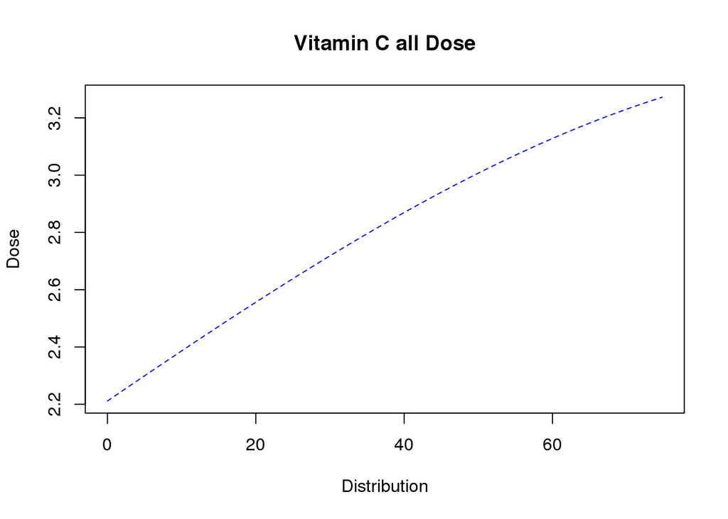

```r
yfit <- dnorm(xfit, mean = mean(pt_vc), sd = sd(pt_vc))
plot(xfit*1000, yfit*1, type="l", lty=2, col ="blue", xlab="Distribution", ylab = "Dose", main="Vitamin C all Dose")
```

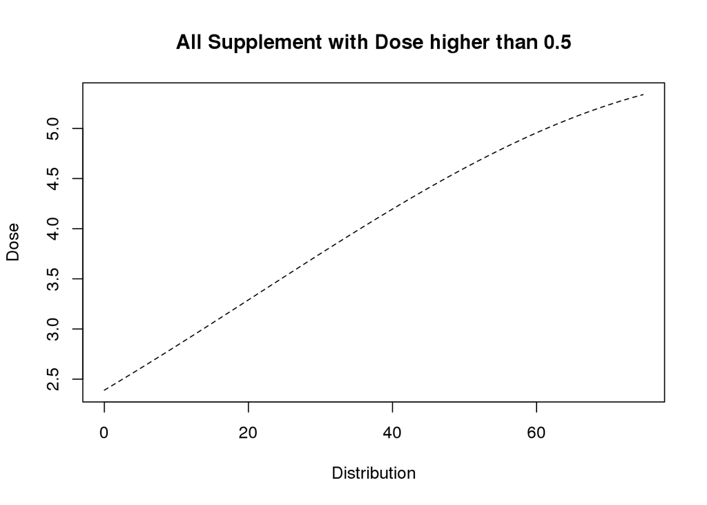

```r
yfit <- dnorm(xfit, mean = mean(pt_gt0_5), sd = sd(pt_gt0_5))
plot(xfit*1000, yfit*1, type="l", lty=2, col ="black", xlab="Distribution", ylab = "Dose", main="All Supplement with Dose higher than 0.5")
```

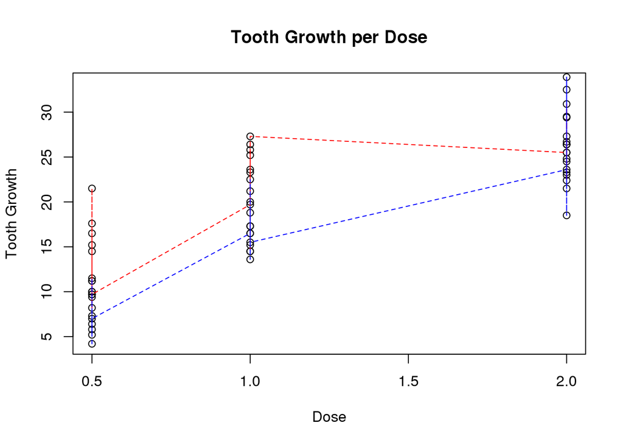

```r
# plotting separate dose to see tooth grow independently
plot(ToothGrowth$dose, ToothGrowth$len, ylim=range(min(ToothGrowth$len):max(ToothGrowth$len)), xlim=range(seq(0.5,2.0,length=3)), col ="black", xlab="Dose", ylab = "Tooth Growth", main="Tooth Growth per Dose")
lines(ojDose$dose, ojDose$len, lty=2, col ="red")
lines(vcDose$dose, vcDose$len, lty=2, col ="blue")
```

The evidence of Tooth Growth is obvious but is it due to Supplements or Dose?

```r
# computing a t.test to find out if Dose is more important than Supplements
tt <- t.test(ojDose$len, vcDose$len, paired = F)
print(tt)
```

```
##
##  Welch Two Sample t-test
##
## data:  ojDose$len and vcDose$len
## t = 1.9153, df = 55.309, p-value = 0.06063
## alternative hypothesis: true difference in means is not equal to 0
## 95 percent confidence interval:
##  -0.1710156  7.5710156
## sample estimates:
## mean of x mean of y
##  20.66333  16.96333
```